# LME Analysis of PNs

### Analysis of H F0

first run: step() suggests: `h_f0 ~ ana_syls + foot_syls + (1 | speaker) + (1 | pn_str_syl)`

model needs trimming: residuals > 3 s.d.

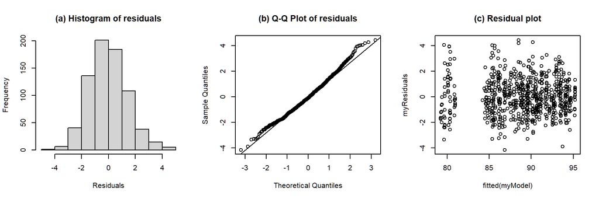

```
## Formula:  h_f0 ~ acc_phon + ana_syls + foot_syls + wrd_end_syl + pn_new_word + (1 | speaker) + (1 | pn_str_syl) + (1 | nuc_pre_text)
##
## Linear mixed model fit by REML. t-tests use Satterthwaite's method [
## lmerModLmerTest]
## Formula: h_f0_equation
##    Data: pn_h_f0.trimmed
## Control:
## lmerControl(optimizer = optimizer, calc.derivs = FALSE, optCtrl = list(method = "nlminb",
##     starttests = FALSE, kkt = FALSE))
##
## REML criterion at convergence: 2697.3
##
## Scaled residuals:
##      Min       1Q   Median       3Q      Max
## -2.89574 -0.69423 -0.07852  0.60037  3.09230
##
## Random effects:
##  Groups       Name        Variance Std.Dev.
##  nuc_pre_text (Intercept)  1.0710  1.035
##  speaker      (Intercept) 17.2112  4.149
##  pn_str_syl   (Intercept)  0.2916  0.540
##  Residual                  2.0552  1.434
## Number of obs: 733, groups:  nuc_pre_text, 12; speaker, 11; pn_str_syl, 8
##
## Fixed effects:
##                 Estimate Std. Error       df t value Pr(>|t|)
## (Intercept)      88.1013     1.7107   8.6797  51.499 4.26e-12 ***
## acc_phon>H*       0.1807     0.2310 702.9923   0.782    0.434
## acc_phonH*        0.1506     0.1824 706.2151   0.826    0.409
## ana_syls1         0.4207     1.2399   3.2005   0.339    0.755
## ana_syls2        -0.1421     1.7832   2.4949  -0.080    0.942
## ana_syls3        -0.7910     1.7844   2.5008  -0.443    0.693
## foot_syls2        0.4565     1.2641   1.8631   0.361    0.755
## foot_syls3        0.6405     1.3780   1.7504   0.465    0.693
## foot_syls4        0.3890     1.5461   2.3666   0.252    0.822
## wrd_end_syl2      1.1454     0.8829   4.7997   1.297    0.253
## wrd_end_syl3     -0.3600     1.0693   8.2828  -0.337    0.745
## pn_new_wordTRUE  -0.4282     1.3162   3.3789  -0.325    0.764
## ---
## Signif. codes:  0 '***' 0.001 '**' 0.01 '*' 0.05 '.' 0.1 ' ' 1
```

[output cut: 40 more lines]

```
## Degrees of freedom method: Satterthwaite
##
##             Eliminated Sum Sq Mean Sq NumDF  DenDF F value    Pr(>F)
## acc_phon             1  2.096  1.0482     2 705.67  0.5076 0.6021829
## pn_new_word          2  2.346  2.3460     1   2.78  1.1375 0.3698098
## wrd_end_syl          3  6.976  3.4879     2  56.54  1.6896 0.1937883
## ana_syls             0 32.748 10.9160     3 264.98  5.2478 0.0015611 **
## foot_syls            0 39.333 13.1109     3 142.69  6.3030 0.0004795 ***
## ---
## Signif. codes:  0 '***' 0.001 '**' 0.01 '*' 0.05 '.' 0.1 ' ' 1
##
## Model found:
## h_f0 ~ ana_syls + foot_syls + (1 | speaker) + (1 | pn_str_syl)
##
## isSingular(my_model, tol = 1e-05 ) --> FALSE
```

ANOVA of model: h_f0 ~ acc_phon + ana_syls + foot_syls + wrd_end_syl + pn_new_word + (1 | speaker) + (1 | pn_str_syl) + (1 | nuc_pre_text)

| term | sumsq | meansq | NumDF | DenDF | F value | p.value | p.adj (BH) | signif. |
| --- | --- | --- | --- | --- | --- | --- | --- | --- |
| acc_phon | 2.01 | 1.01 | 2 | 704 | 0.49 | .613 | .788 |  |
| ana_syls | 12.71 | 4.24 | 3 | 2.87 | 2.06 | .290 | .528 |  |
| foot_syls | 0.5 | 0.16 | 3 | 2 | 0.08 | .965 | .966 |  |
| wrd_end_syl | 16.08 | 8.04 | 2 | 8.97 | 3.91 | .060 | .166 |  |
| pn_new_word | 0.22 | 0.22 | 1 | 3.38 | 0.11 | .764 | .908 |  |

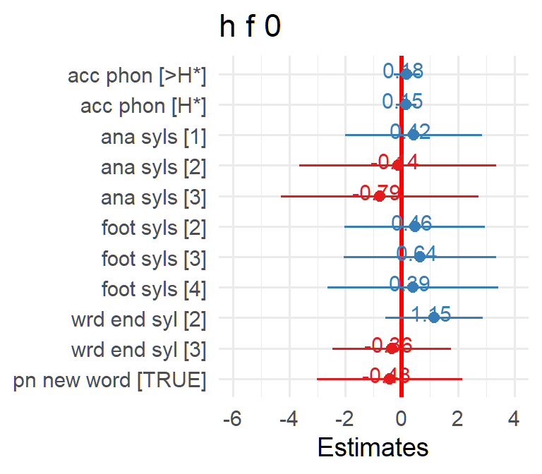

Conditional and marginal R<sup>2</sup> of model

| R2_conditional | R2_marginal |
| --- | --- |
| 0.9 | 0.02 |

$acc_phon

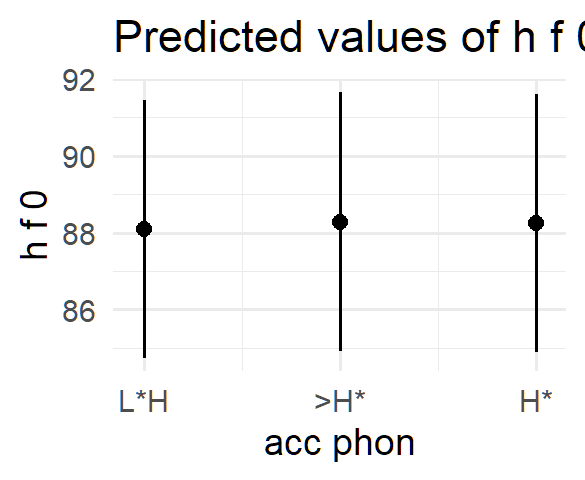

$ana_syls

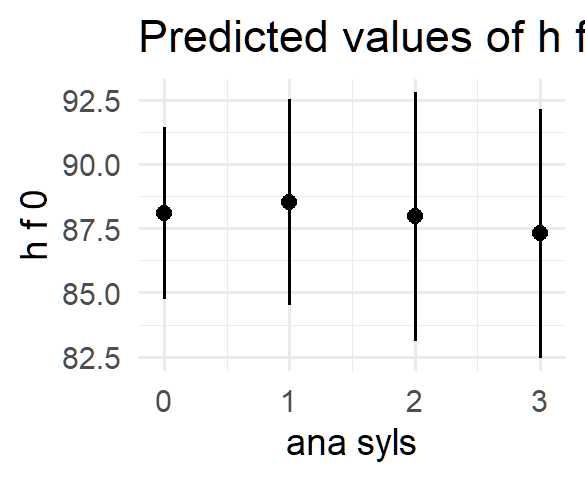

$foot_syls

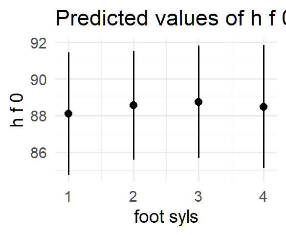

$wrd_end_syl

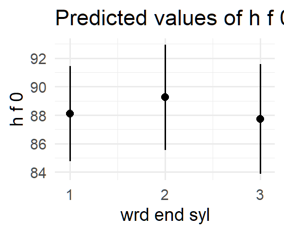

$pn_new_word

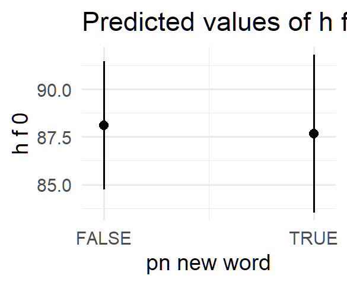

summary of model: h_f0 ~ acc_phon + ana_syls + foot_syls + wrd_end_syl + pn_new_word + (1 | speaker) + (1 | pn_str_syl) + (1 | nuc_pre_text)

| term | estimate | conf.low | conf.high | std.error | t.value | df | p.value |
| --- | --- | --- | --- | --- | --- | --- | --- |
| (Intercept) | 88.101 | 84.2094792 | 91.9930820 | 1.711 | 51.499 | 8.68 | 4.3e-12 |
| acc_phon>H* | 0.181 | -0.2728422 | 0.6343090 | 0.231 | 0.782 | 702.99 | 0.4343 |
| acc_phonH* | 0.151 | -0.2075349 | 0.5087694 | 0.182 | 0.826 | 706.22 | 0.4093 |
| ana_syls1 | 0.421 | -3.3888224 | 4.2302676 | 1.240 | 0.339 | 3.20 | 0.7554 |
| ana_syls2 | -0.142 | -6.5260601 | 6.2417771 | 1.783 | -0.080 | 2.49 | 0.9424 |
| ana_syls3 | -0.791 | -7.1680742 | 5.5861405 | 1.784 | -0.443 | 2.50 | 0.693 |
| foot_syls2 | 0.456 | -5.3837356 | 6.2966851 | 1.264 | 0.361 | 1.86 | 0.7548 |
| foot_syls3 | 0.641 | -6.1770649 | 7.4580776 | 1.378 | 0.465 | 1.75 | 0.6934 |
| foot_syls4 | 0.389 | -5.3669269 | 6.1449403 | 1.546 | 0.252 | 2.37 | 0.8215 |
| wrd_end_syl2 | 1.145 | -1.1528593 | 3.4437308 | 0.883 | 1.297 | 4.80 | 0.2534 |
| wrd_end_syl3 | -0.360 | -2.8112628 | 2.0913474 | 1.069 | -0.337 | 8.28 | 0.7448 |
| pn_new_wordTRUE | -0.428 | -4.3632585 | 3.5068748 | 1.316 | -0.325 | 3.38 | 0.7641 |

b0 for h_f0 ~ acc_phon + ana_syls + foot_syls + wrd_end_syl + pn_new_word + (1 | speaker) + (1 | pn_str_syl) + (1 | nuc_pre_text)

| intercept | estimate | conf.low | conf.high | std.error | t.value | df | p.value |
| --- | --- | --- | --- | --- | --- | --- | --- |
| acc_phonL*H | 88.1 | 84.2 | 92 | 1.71 | 51.50 | 8.68 | 4.3e-12 |
| acc_phon>H* | 88.3 | 84.4 | 92.2 | 1.72 | 51.28 | 8.91 | 2.6e-12 |
| acc_phonH* | 88.2 | 84.4 | 92.1 | 1.71 | 51.57 | 8.68 | 4.2e-12 |
| ana_syls0 | 88.1 | 84.2 | 92 | 1.71 | 51.50 | 8.68 | 4.3e-12 |
| ana_syls1 | 88.5 | 83.4 | 93.6 | 2.05 | 43.23 | 5.64 | 2.5e-08 |
| ana_syls2 | 88 | 81.2 | 94.7 | 2.47 | 35.61 | 4.13 | 2.7e-06 |
| ana_syls3 | 87.3 | 80.5 | 94.1 | 2.47 | 35.34 | 4.14 | 2.7e-06 |
| foot_syls1 | 88.1 | 84.2 | 92 | 1.71 | 51.50 | 8.68 | 4.3e-12 |
| foot_syls2 | 88.6 | 85.3 | 91.8 | 1.52 | 58.39 | 13.53 | 1.2e-17 |
| foot_syls3 | 88.7 | 85.3 | 92.2 | 1.57 | 56.64 | 12.00 | 6.1e-16 |
| foot_syls4 | 88.5 | 84.8 | 92.2 | 1.71 | 51.69 | 12.70 | 3.8e-16 |
| wrd_end_syl1 | 88.1 | 84.2 | 92 | 1.71 | 51.50 | 8.68 | 4.3e-12 |
| wrd_end_syl2 | 89.2 | 84.8 | 93.7 | 1.89 | 47.33 | 7.06 | 4.3e-10 |
| wrd_end_syl3 | 87.7 | 83.1 | 92.3 | 1.96 | 44.67 | 7.37 | 3.0e-10 |

b1 for h_f0 ~ acc_phon + ana_syls + foot_syls + wrd_end_syl + pn_new_word + (1 | speaker) + (1 | pn_str_syl) + (1 | nuc_pre_text)

| intercept | slope | estimate | conf.low | conf.high | std.error | t.value | df | p.value |
| --- | --- | --- | --- | --- | --- | --- | --- | --- |
| acc_phonL*H | acc_phon>H* | 0.18 | -0.273 | 0.634 | 0.230 | 0.780 | 702.99 | 0.434 |
| acc_phonL*H | acc_phonH* | 0.15 | -0.208 | 0.509 | 0.180 | 0.830 | 706.22 | 0.409 |
| acc_phon>H* | acc_phonH* | -0.03 | -0.509 | 0.449 | 0.240 | -0.120 | 701.32 | 0.902 |
| ana_syls0 | ana_syls1 | 0.42 | -3.389 | 4.23 | 1.240 | 0.340 | 3.20 | 0.755 |
| ana_syls0 | ana_syls2 | -0.14 | -6.526 | 6.242 | 1.780 | -0.080 | 2.49 | 0.942 |
| ana_syls0 | ana_syls3 | -0.79 | -7.168 | 5.586 | 1.780 | -0.440 | 2.50 | 0.693 |
| ana_syls1 | ana_syls2 | -0.56 | -6.275 | 5.149 | 1.310 | -0.430 | 1.97 | 0.71 |
| ana_syls1 | ana_syls3 | -1.21 | -6.917 | 4.494 | 1.310 | -0.930 | 1.97 | 0.454 |
| ana_syls2 | ana_syls3 | -0.65 | -1.186 | -0.112 | 0.270 | -2.370 | 701.14 | 0.018 |
| foot_syls1 | foot_syls2 | 0.46 | -5.384 | 6.297 | 1.260 | 0.360 | 1.86 | 0.755 |
| foot_syls1 | foot_syls3 | 0.64 | -6.177 | 7.458 | 1.380 | 0.460 | 1.75 | 0.693 |
| foot_syls1 | foot_syls4 | 0.39 | -5.367 | 6.145 | 1.550 | 0.250 | 2.37 | 0.822 |
| foot_syls2 | foot_syls3 | 0.18 | -4.231 | 4.599 | 1.140 | 0.160 | 2.25 | 0.885 |
| foot_syls2 | foot_syls4 | -0.07 | -4.207 | 4.072 | 1.310 | -0.050 | 3.03 | 0.962 |
| foot_syls3 | foot_syls4 | -0.25 | -4.514 | 4.011 | 1.130 | -0.220 | 2.33 | 0.842 |
| wrd_end_syl1 | wrd_end_syl2 | 1.15 | -1.153 | 3.444 | 0.880 | 1.300 | 4.80 | 0.253 |
| wrd_end_syl1 | wrd_end_syl3 | -0.36 | -2.811 | 2.091 | 1.070 | -0.340 | 8.28 | 0.745 |
| wrd_end_syl2 | wrd_end_syl3 | -1.51 | -2.716 | -0.295 | 0.610 | -2.480 | 68.29 | 0.016 |
| intercept | pn_new_wordTRUE | -0.428 | -4.363 | 3.507 | 1.316 | -0.325 | 3.38 | 0.764 |

## Truncation and Compression Effects

Based on results from tonal target analysis, it looks there is an element of truncation in LH contours as a function of foot size, alongside a degree of rightward drift in L targets as foot size increases. However, superficially, it looks like the slope is stable.

As with nuclear data, I am retaining the overall model structure as much as possible BUT will discard all but foot_syls for analysis.

### LH Excursion

- first run, step() suggests: `f0_exc ~ ana_syls + foot_syls + (1 | speaker) + (1 | pn_str_syl)`
- model needs trimming (|sd| residuals > 2.5)

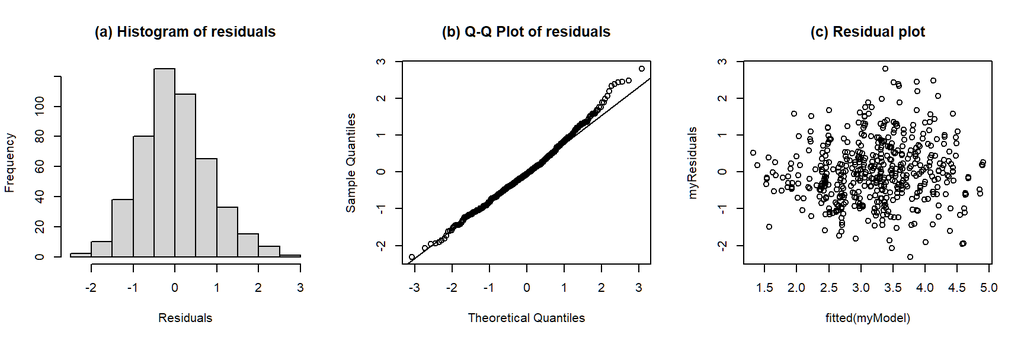

```
## Formula:  f0_exc ~ ana_syls + foot_syls + wrd_end_syl + pn_new_word + gender + (1 | speaker) + (1 | pn_str_syl) + (1 | nuc_pre_text) + (1 | speech_rate)
##
## Linear mixed model fit by REML. t-tests use Satterthwaite's method [
## lmerModLmerTest]
## Formula: f0_exc_equation
##    Data: pn_f0_exc.trimmed
## Control:
## lmerControl(optimizer = optimizer, calc.derivs = FALSE, optCtrl = list(method = "nlminb",
##     starttests = FALSE, kkt = FALSE))
##
## REML criterion at convergence: 1313.5
##
## Scaled residuals:
##     Min      1Q  Median      3Q     Max
## -2.6394 -0.6287 -0.0645  0.5703  3.2104
##
## Random effects:
##  Groups       Name        Variance  Std.Dev.
##  speech_rate  (Intercept) 3.840e-02 0.1959633
##  nuc_pre_text (Intercept) 1.229e-08 0.0001108
##  speaker      (Intercept) 1.675e-01 0.4092516
##  pn_str_syl   (Intercept) 5.641e-01 0.7510707
##  Residual                 7.637e-01 0.8739100
## Number of obs: 484, groups:
## speech_rate, 415; nuc_pre_text, 12; speaker, 11; pn_str_syl, 8
##
## Fixed effects:
##                   Estimate Std. Error         df t value Pr(>|t|)
## (Intercept)       2.171794   0.477293  14.897665   4.550 0.000389 ***
## ana_syls1        -0.006225   0.862756   4.277524  -0.007 0.994568
## ana_syls2         0.986864   0.871073   4.557546   1.133 0.313301
## ana_syls3         0.541379   0.872723   4.578025   0.620 0.564600
## foot_syls2        0.605606   0.256835 309.847888   2.358 0.018997 *
## foot_syls3        0.852694   0.248182 357.849633   3.436 0.000660 ***
## foot_syls4        0.589721   0.302540 276.860903   1.949 0.052277 .
## wrd_end_syl2      0.131857   0.187809 349.620215   0.702 0.483094
## wrd_end_syl3      0.144324   0.410658  88.351027   0.351 0.726091
## pn_new_wordTRUE  -0.778260   0.838778   4.159970  -0.928 0.404116
## genderM           0.538389   0.267120   9.193714   2.016 0.073995 .
## ---
```

[output cut: 40 more lines]

```
## Degrees of freedom method: Satterthwaite
##
##             Eliminated  Sum Sq Mean Sq NumDF  DenDF F value    Pr(>F)
## wrd_end_syl          1  0.4473  0.2237     2 128.39  0.2789  0.757103
## pn_new_word          2  0.7759  0.7759     1   4.34  0.9701  0.376341
## gender               3  3.2282  3.2282     1   9.19  4.0341  0.074870 .
## ana_syls             0 25.2693  8.4231     3 415.13 10.5305 1.092e-06 ***
## foot_syls            0 11.8173  3.9391     3 313.95  4.9246  0.002342 **
## ---
## Signif. codes:  0 '***' 0.001 '**' 0.01 '*' 0.05 '.' 0.1 ' ' 1
##
## Model found:
## f0_exc ~ ana_syls + foot_syls + (1 | speaker) + (1 | pn_str_syl)
##
## isSingular(my_model, tol = 1e-05 ) --> FALSE
```

ANOVA of model: f0_exc ~ ana_syls + foot_syls + wrd_end_syl + pn_new_word + gender + (1 | speaker) + (1 | pn_str_syl) + (1 | nuc_pre_text) + (1 | speech_rate)

| term | sumsq | meansq | NumDF | DenDF | F value | p.value | p.adj (BH) | signif. |
| --- | --- | --- | --- | --- | --- | --- | --- | --- |
| ana_syls | 21.87 | 7.29 | 3 | 8.95 | 9.55 | .004 | .014 | p<.05 |
| foot_syls | 10.45 | 3.48 | 3 | 321.9 | 4.56 | .004 | .014 | p<.05 |
| wrd_end_syl | 0.38 | 0.19 | 2 | 127.63 | 0.25 | .782 | .908 |  |
| pn_new_word | 0.66 | 0.66 | 1 | 4.16 | 0.86 | .404 | .606 |  |
| gender | 3.1 | 3.1 | 1 | 9.19 | 4.06 | .074 | .190 |  |

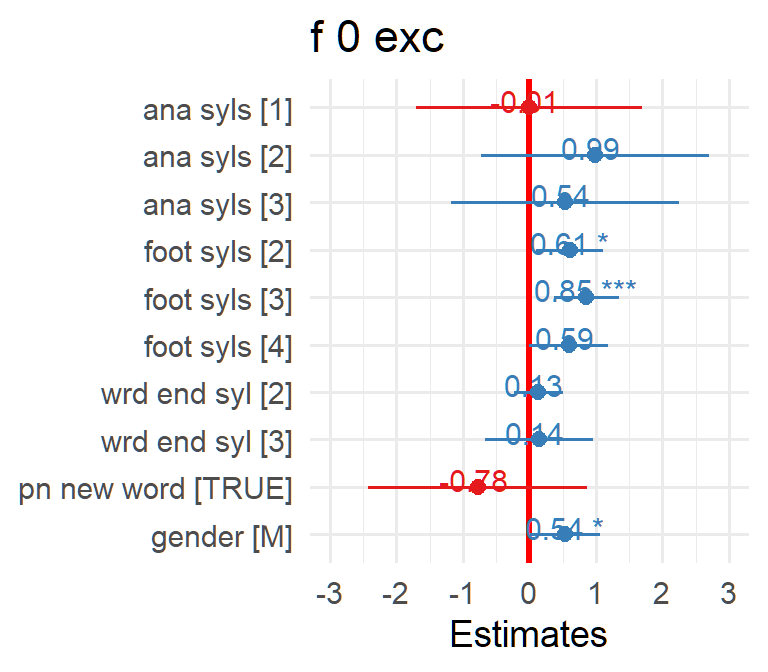

Conditional and marginal R<sup>2</sup> of model

| R2_conditional | R2_marginal |
| --- | --- |
| 0.59 | 0.17 |

$ana_syls

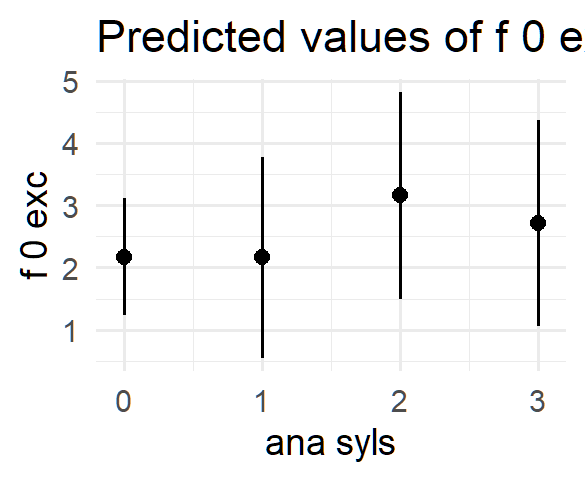

$foot_syls

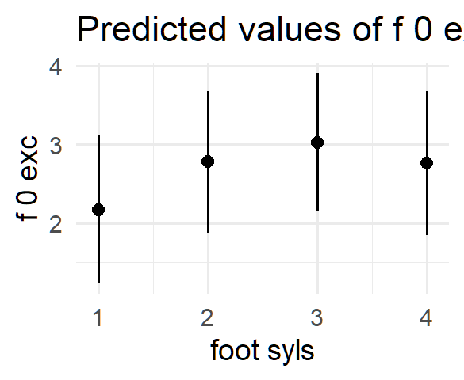

$wrd_end_syl

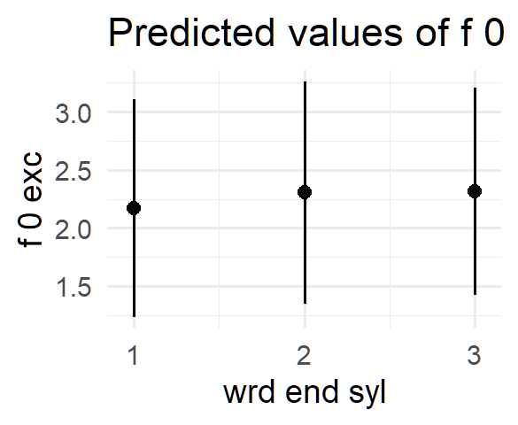

$pn_new_word

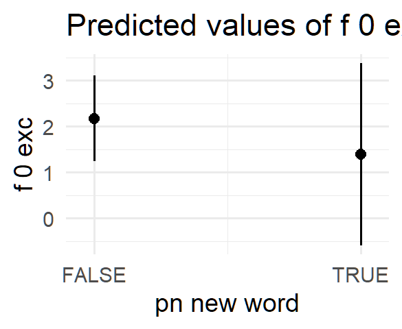

$gender

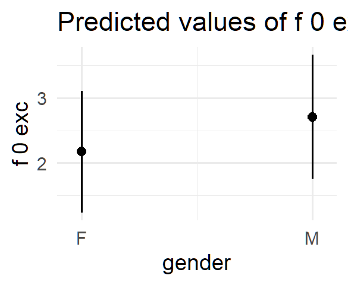

summary of model: f0_exc ~ ana_syls + foot_syls + wrd_end_syl + pn_new_word + gender + (1 | speaker) + (1 | pn_str_syl) + (1 | nuc_pre_text) + (1 | speech_rate)

| term | estimate | conf.low | conf.high | std.error | t.value | df | p.value |
| --- | --- | --- | --- | --- | --- | --- | --- |
| (Intercept) | 2.172 | 1.153857819 | 3.1897292 | 0.477 | 4.550 | 14.90 | 4e-04 |
| ana_syls1 | -0.006 | -2.341556218 | 2.3291069 | 0.863 | -0.007 | 4.28 | 0.9946 |
| ana_syls2 | 0.987 | -1.319289679 | 3.2930182 | 0.871 | 1.133 | 4.56 | 0.3133 |
| ana_syls3 | 0.541 | -1.765671779 | 2.8484297 | 0.873 | 0.620 | 4.58 | 0.5646 |
| foot_syls2 | 0.606 | 0.100244275 | 1.1109672 | 0.257 | 2.358 | 309.85 | 0.019 |
| foot_syls3 | 0.853 | 0.364614600 | 1.3407727 | 0.248 | 3.436 | 357.85 | 7e-04 |
| foot_syls4 | 0.590 | -0.005848986 | 1.1852911 | 0.303 | 1.949 | 276.86 | 0.0523 |
| wrd_end_syl2 | 0.132 | -0.237519369 | 0.5012341 | 0.188 | 0.702 | 349.62 | 0.4831 |
| wrd_end_syl3 | 0.144 | -0.671726910 | 0.9603746 | 0.411 | 0.351 | 88.35 | 0.7261 |
| pn_new_wordTRUE | -0.778 | -3.072183092 | 1.5156639 | 0.839 | -0.928 | 4.16 | 0.4041 |
| genderM | 0.538 | -0.063943595 | 1.1407214 | 0.267 | 2.016 | 9.19 | 0.074 |

b0 for f0_exc ~ ana_syls + foot_syls + wrd_end_syl + pn_new_word + gender + (1 | speaker) + (1 | pn_str_syl) + (1 | nuc_pre_text) + (1 | speech_rate)

| intercept | estimate | conf.low | conf.high | std.error | t.value | df | p.value |
| --- | --- | --- | --- | --- | --- | --- | --- |
| ana_syls0 | 2.17 | 1.154 | 3.19 | 0.48 | 4.55 | 14.90 | 3.9e-04 |
| ana_syls1 | 2.17 | 0.047 | 4.284 | 0.82 | 2.63 | 4.97 | 0.047 |
| ana_syls2 | 3.16 | 1.052 | 5.265 | 0.85 | 3.73 | 5.60 | 0.011 |
| ana_syls3 | 2.71 | 0.607 | 4.819 | 0.85 | 3.21 | 5.59 | 0.02 |
| foot_syls1 | 2.17 | 1.154 | 3.19 | 0.48 | 4.55 | 14.90 | 3.9e-04 |
| foot_syls2 | 2.78 | 1.793 | 3.762 | 0.46 | 6.06 | 13.68 | 3.2e-05 |
| foot_syls3 | 3.02 | 2.04 | 4.009 | 0.45 | 6.72 | 11.59 | 2.5e-05 |
| foot_syls4 | 2.76 | 1.752 | 3.771 | 0.47 | 5.91 | 13.04 | 5.1e-05 |
| wrd_end_syl1 | 2.17 | 1.154 | 3.19 | 0.48 | 4.55 | 14.90 | 3.9e-04 |
| wrd_end_syl2 | 2.3 | 1.268 | 3.339 | 0.49 | 4.72 | 15.70 | 2.4e-04 |
| wrd_end_syl3 | 2.32 | 1.365 | 3.267 | 0.45 | 5.10 | 18.93 | 6.5e-05 |

b1 for f0_exc ~ ana_syls + foot_syls + wrd_end_syl + pn_new_word + gender + (1 | speaker) + (1 | pn_str_syl) + (1 | nuc_pre_text) + (1 | speech_rate)

| intercept | slope | estimate | conf.low | conf.high | std.error | t.value | df | p.value |
| --- | --- | --- | --- | --- | --- | --- | --- | --- |
| ana_syls0 | ana_syls1 | -0.01 | -2.342 | 2.329 | 0.860 | -0.010 | 4.28 | 0.995 |
| ana_syls0 | ana_syls2 | 0.99 | -1.319 | 3.293 | 0.870 | 1.130 | 4.56 | 0.313 |
| ana_syls0 | ana_syls3 | 0.54 | -1.766 | 2.848 | 0.870 | 0.620 | 4.58 | 0.565 |
| ana_syls1 | ana_syls2 | 0.99 | 0.628 | 1.359 | 0.190 | 5.340 | 434.97 | 1.5e-07 |
| ana_syls1 | ana_syls3 | 0.55 | 0.183 | 0.912 | 0.190 | 2.950 | 449.93 | 0.003 |
| ana_syls2 | ana_syls3 | -0.45 | -0.795 | -0.096 | 0.180 | -2.500 | 450.89 | 0.013 |
| foot_syls1 | foot_syls2 | 0.61 | 0.1 | 1.111 | 0.260 | 2.360 | 309.85 | 0.019 |
| foot_syls1 | foot_syls3 | 0.85 | 0.365 | 1.341 | 0.250 | 3.440 | 357.85 | 6.6e-04 |
| foot_syls1 | foot_syls4 | 0.59 | -0.006 | 1.185 | 0.300 | 1.950 | 276.86 | 0.052 |
| foot_syls2 | foot_syls3 | 0.25 | -0.189 | 0.683 | 0.220 | 1.110 | 347.75 | 0.266 |
| foot_syls2 | foot_syls4 | -0.02 | -0.568 | 0.536 | 0.280 | -0.060 | 250.04 | 0.955 |
| foot_syls3 | foot_syls4 | -0.26 | -0.621 | 0.095 | 0.180 | -1.440 | 419.20 | 0.15 |
| wrd_end_syl1 | wrd_end_syl2 | 0.13 | -0.238 | 0.501 | 0.190 | 0.700 | 349.62 | 0.483 |
| wrd_end_syl1 | wrd_end_syl3 | 0.14 | -0.672 | 0.96 | 0.410 | 0.350 | 88.35 | 0.726 |
| wrd_end_syl2 | wrd_end_syl3 | 0.01 | -0.712 | 0.737 | 0.360 | 0.030 | 58.97 | 0.973 |
| intercept | pn_new_wordTRUE | -0.778 | -3.072 | 1.516 | 0.839 | -0.928 | 4.16 | 0.404 |
| intercept | genderM | 0.538 | -0.064 | 1.141 | 0.267 | 2.016 | 9.19 | 0.074 |

### LH Slope

- first run of step suggests: `log_lh_slope ~ foot_syls + gender + (1 | speaker) + (1 | nuc_pre_text)`
- Keeping all fixed effects to check effects.
- model needs trimming (|sd| residuals > 3.5)
- data needs trimming: residual SD > 4

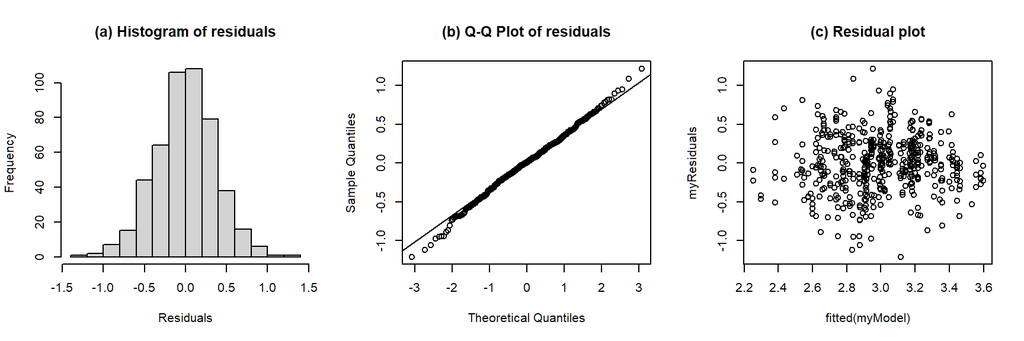

```
## Formula:  log_lh_slope ~ ana_syls + foot_syls + wrd_end_syl + pn_new_word + gender + (1 | speaker) + (1 | nuc_pre_text)
##
## Linear mixed model fit by REML. t-tests use Satterthwaite's method [
## lmerModLmerTest]
## Formula: lh_slope_equation
##    Data: pn_lh_slope.trimmed
## Control:
## lmerControl(optimizer = optimizer, calc.derivs = FALSE, optCtrl = list(method = "nlminb",
##     starttests = FALSE, kkt = FALSE))
##
## REML criterion at convergence: 492.7
##
## Scaled residuals:
##     Min      1Q  Median      3Q     Max
## -3.2157 -0.5951  0.0132  0.6284  3.2261
##
## Random effects:
##  Groups       Name        Variance Std.Dev.
##  nuc_pre_text (Intercept) 0.04955  0.2226
##  speaker      (Intercept) 0.02121  0.1456
##  Residual                 0.14166  0.3764
## Number of obs: 488, groups:  nuc_pre_text, 12; speaker, 11
##
## Fixed effects:
##                  Estimate Std. Error        df t value Pr(>|t|)
## (Intercept)      2.897613   0.244300  3.797793  11.861 0.000386 ***
## ana_syls1       -0.030115   0.230364  3.081936  -0.131 0.904059
## ana_syls2        0.132177   0.358562  3.236735   0.369 0.735210
## ana_syls3       -0.003956   0.358926  3.245570  -0.011 0.991850
## foot_syls2      -0.496992   0.271005  3.292527  -1.834 0.155803
## foot_syls3      -0.134000   0.303715  3.434431  -0.441 0.685390
## foot_syls4       0.012533   0.333177  3.816589   0.038 0.971879
## wrd_end_syl2     0.008094   0.198158  5.659187   0.041 0.968821
## wrd_end_syl3    -0.031732   0.248666  9.689304  -0.128 0.901068
## pn_new_wordTRUE  0.157200   0.250756  4.012242   0.627 0.564628
## genderM          0.269612   0.097317  9.302663   2.770 0.021091 *
## ---
## Signif. codes:  0 '***' 0.001 '**' 0.01 '*' 0.05 '.' 0.1 ' ' 1
##
## Correlation of Fixed Effects:
```

[output cut: 35 more lines]

```
## Degrees of freedom method: Satterthwaite
##
##             Eliminated  Sum Sq Mean Sq NumDF   DenDF F value  Pr(>F)
## wrd_end_syl          1 0.00992 0.00496     2 10.2882  0.0350 0.96570
## pn_new_word          2 0.06088 0.06088     1  5.3143  0.4302 0.53922
## ana_syls             3 0.71953 0.23984     3  7.1606  1.6927 0.25297
## foot_syls            0 2.24618 0.74873     3  7.1108  5.2416 0.03218 *
## gender               0 1.09984 1.09984     1  9.3187  7.6996 0.02091 *
## ---
## Signif. codes:  0 '***' 0.001 '**' 0.01 '*' 0.05 '.' 0.1 ' ' 1
##
## Model found:
## log_lh_slope ~ foot_syls + gender + (1 | speaker) + (1 | nuc_pre_text)
##
## isSingular(my_model, tol = 1e-05 ) --> FALSE
```

ANOVA of model: log_lh_slope ~ ana_syls + foot_syls + wrd_end_syl + pn_new_word + gender + (1 | speaker) + (1 | nuc_pre_text)

| term | sumsq | meansq | NumDF | DenDF | F value | p.value | p.adj (BH) | signif. |
| --- | --- | --- | --- | --- | --- | --- | --- | --- |
| ana_syls | 0.5 | 0.17 | 3 | 3.73 | 1.17 | .431 | .621 |  |
| foot_syls | 0.73 | 0.24 | 3 | 3.71 | 1.72 | .308 | .528 |  |
| wrd_end_syl | 0.01 | 5.0e-03 | 2 | 10.29 | 0.04 | .966 | .966 |  |
| pn_new_word | 0.06 | 0.06 | 1 | 4.01 | 0.39 | .565 | .753 |  |
| gender | 1.09 | 1.09 | 1 | 9.3 | 7.68 | .021 | .063 |  |

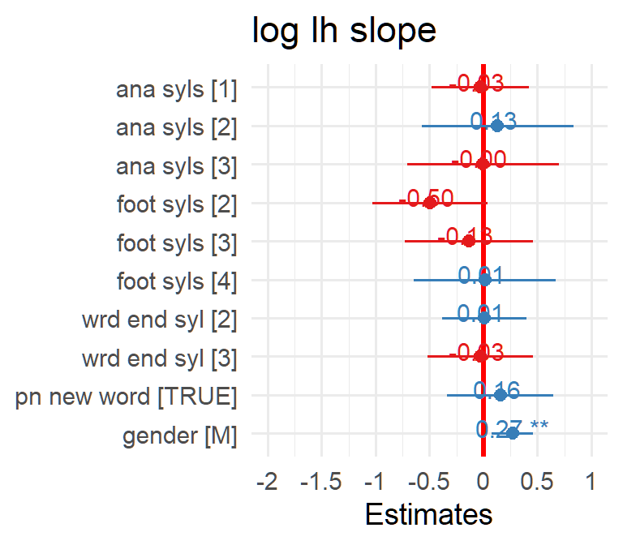

Conditional and marginal R<sup>2</sup> of model

| R2_conditional | R2_marginal |
| --- | --- |
| 0.49 | 0.23 |

$ana_syls

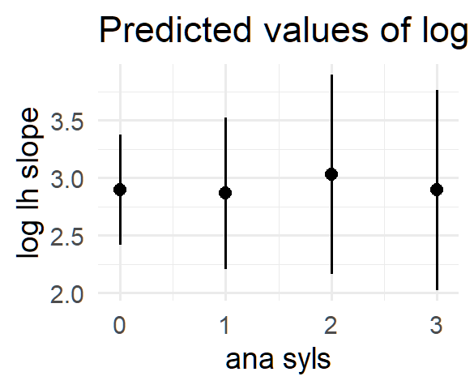

$foot_syls

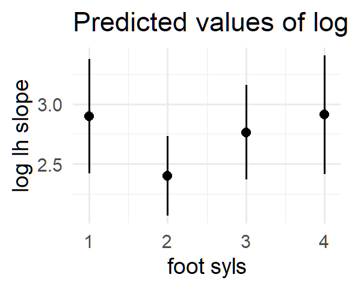

$wrd_end_syl

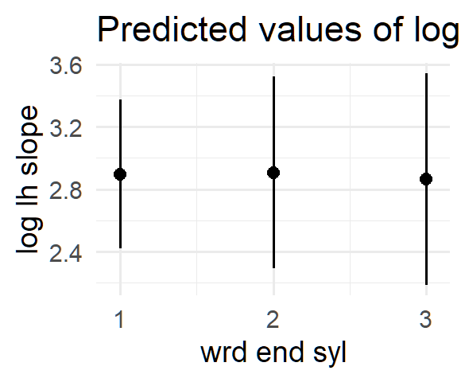

$pn_new_word

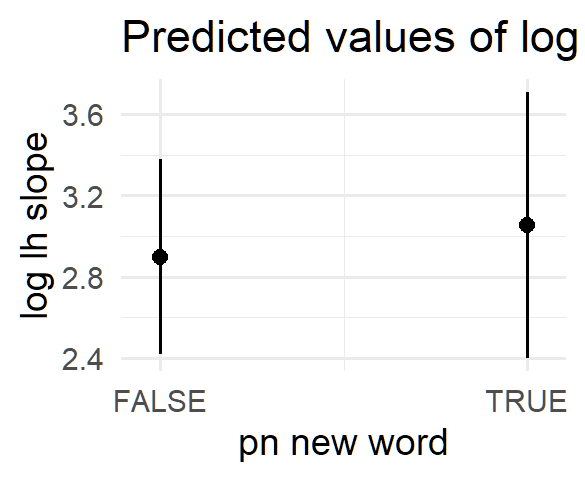

$gender

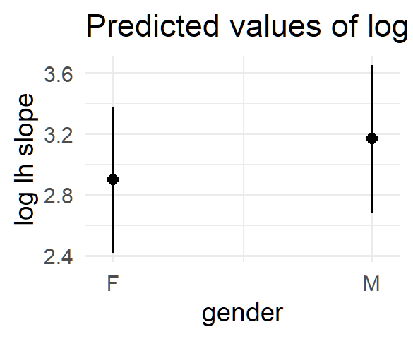

summary of model: log_lh_slope ~ ana_syls + foot_syls + wrd_end_syl + pn_new_word + gender + (1 | speaker) + (1 | nuc_pre_text)

| term | estimate | conf.low | conf.high | std.error | t.value | df | p.value |
| --- | --- | --- | --- | --- | --- | --- | --- |
| (Intercept) | 2.898 | 2.20484319 | 3.5903821 | 0.244 | 11.861 | 3.80 | 4e-04 |
| ana_syls1 | -0.030 | -0.75233145 | 0.6921012 | 0.230 | -0.131 | 3.08 | 0.9041 |
| ana_syls2 | 0.132 | -0.96313518 | 1.2274883 | 0.359 | 0.369 | 3.24 | 0.7352 |
| ana_syls3 | -0.004 | -1.09884880 | 1.0909378 | 0.359 | -0.011 | 3.25 | 0.9919 |
| foot_syls2 | -0.497 | -1.31768185 | 0.3236974 | 0.271 | -1.834 | 3.29 | 0.1558 |
| foot_syls3 | -0.134 | -1.03493970 | 0.7669396 | 0.304 | -0.441 | 3.43 | 0.6854 |
| foot_syls4 | 0.013 | -0.93031316 | 0.9553783 | 0.333 | 0.038 | 3.82 | 0.9719 |
| wrd_end_syl2 | 0.008 | -0.48394701 | 0.5001350 | 0.198 | 0.041 | 5.66 | 0.9688 |
| wrd_end_syl3 | -0.032 | -0.58821151 | 0.5247476 | 0.249 | -0.128 | 9.69 | 0.9011 |
| pn_new_wordTRUE | 0.157 | -0.53817364 | 0.8525729 | 0.251 | 0.627 | 4.01 | 0.5646 |
| genderM | 0.270 | 0.05055301 | 0.4886705 | 0.097 | 2.770 | 9.30 | 0.0211 |

b0 for log_lh_slope ~ ana_syls + foot_syls + wrd_end_syl + pn_new_word + gender + (1 | speaker) + (1 | nuc_pre_text)

| intercept | estimate | conf.low | conf.high | std.error | t.value | df | p.value |
| --- | --- | --- | --- | --- | --- | --- | --- |
| ana_syls0 | 2.9 | 2.205 | 3.59 | 0.24 | 11.86 | 3.80 | 3.9e-04 |
| ana_syls1 | 2.87 | 1.872 | 3.863 | 0.34 | 8.53 | 3.44 | 0.002 |
| ana_syls2 | 3.03 | 1.746 | 4.313 | 0.44 | 6.85 | 3.60 | 0.003 |
| ana_syls3 | 2.89 | 1.61 | 4.177 | 0.44 | 6.54 | 3.60 | 0.004 |
| foot_syls1 | 2.9 | 2.205 | 3.59 | 0.24 | 11.86 | 3.80 | 3.9e-04 |
| foot_syls2 | 2.4 | 1.998 | 2.803 | 0.17 | 14.30 | 6.55 | 3.5e-06 |
| foot_syls3 | 2.76 | 2.224 | 3.303 | 0.20 | 13.78 | 4.36 | 9.2e-05 |
| foot_syls4 | 2.91 | 2.285 | 3.536 | 0.25 | 11.54 | 5.69 | 3.7e-05 |
| wrd_end_syl1 | 2.9 | 2.205 | 3.59 | 0.24 | 11.86 | 3.80 | 3.9e-04 |
| wrd_end_syl2 | 2.91 | 2.064 | 3.747 | 0.31 | 9.27 | 4.38 | 4.8e-04 |
| wrd_end_syl3 | 2.87 | 2.003 | 3.729 | 0.35 | 8.29 | 5.53 | 2.5e-04 |

b1 for log_lh_slope ~ ana_syls + foot_syls + wrd_end_syl + pn_new_word + gender + (1 | speaker) + (1 | nuc_pre_text)

| intercept | slope | estimate | conf.low | conf.high | std.error | t.value | df | p.value |
| --- | --- | --- | --- | --- | --- | --- | --- | --- |
| ana_syls0 | ana_syls1 | -0.03 | -0.752 | 0.692 | 0.230 | -0.130 | 3.08 | 0.904 |
| ana_syls0 | ana_syls2 | 0.13 | -0.963 | 1.227 | 0.360 | 0.370 | 3.24 | 0.735 |
| ana_syls0 | ana_syls3 | -0.0e+00 | -1.099 | 1.091 | 0.360 | -0.010 | 3.25 | 0.992 |
| ana_syls1 | ana_syls2 | 0.16 | -0.662 | 0.987 | 0.270 | 0.590 | 3.35 | 0.592 |
| ana_syls1 | ana_syls3 | 0.03 | -0.798 | 0.85 | 0.280 | 0.100 | 3.36 | 0.93 |
| ana_syls2 | ana_syls3 | -0.14 | -0.282 | 0.01 | 0.070 | -1.830 | 462.60 | 0.067 |
| foot_syls1 | foot_syls2 | -0.5 | -1.318 | 0.324 | 0.270 | -1.830 | 3.29 | 0.156 |
| foot_syls1 | foot_syls3 | -0.13 | -1.035 | 0.767 | 0.300 | -0.440 | 3.43 | 0.685 |
| foot_syls1 | foot_syls4 | 0.01 | -0.93 | 0.955 | 0.330 | 0.040 | 3.82 | 0.972 |
| foot_syls2 | foot_syls3 | 0.36 | -0.321 | 1.047 | 0.250 | 1.460 | 4.10 | 0.216 |
| foot_syls2 | foot_syls4 | 0.51 | -0.242 | 1.261 | 0.280 | 1.790 | 4.61 | 0.139 |
| foot_syls3 | foot_syls4 | 0.15 | -0.536 | 0.829 | 0.240 | 0.610 | 3.76 | 0.576 |
| wrd_end_syl1 | wrd_end_syl2 | 0.01 | -0.484 | 0.5 | 0.200 | 0.040 | 5.66 | 0.969 |
| wrd_end_syl1 | wrd_end_syl3 | -0.03 | -0.588 | 0.525 | 0.250 | -0.130 | 9.69 | 0.901 |
| wrd_end_syl2 | wrd_end_syl3 | -0.04 | -0.347 | 0.267 | 0.150 | -0.260 | 41.77 | 0.795 |
| intercept | pn_new_wordTRUE | 0.157 | -0.538 | 0.853 | 0.251 | 0.627 | 4.01 | 0.565 |
| intercept | genderM | 0.27 | 0.051 | 0.489 | 0.097 | 2.770 | 9.30 | 0.021 |